# Housing Prices Prediction

Xiangyu Liu

March, 2018

# 1 Data preparation

## 1.1 *R* Libraries

Let the fun begin!

```r
library(ggthemes)
library(cowplot)
library(gridExtra)
library(ggplot2)
library(moments)
library(knitr)
library(dplyr)
library(caret)
library(glmnet)
```

## 1.2 Importing the data

```r
train <- read.csv("/Users/xiangyu/Desktop/house prediction/input/train.csv",stringsAsFactors = FALSE)
test <- read.csv("/Users/xiangyu/Desktop/house prediction/input/test.csv",stringsAsFactors = FALSE)
allSet <- bind_rows(train,test)
```

## 1.3 Imputing missing values with default, median, mode or regression

First, let’s see the missing values for the whole dataset.

```r
checkNAs <- function(df){
        naCols <- which(colSums(is.na(df))>0)
        sort(colSums(sapply(allSet[naCols],is.na)), decreasing = TRUE)
}
checkNAs(allSet)
```

```
##       PoolQC  MiscFeature        Alley        Fence    SalePrice
##         2909         2814         2721         2348         1459
##  FireplaceQu  LotFrontage  GarageYrBlt GarageFinish   GarageQual
##         1420          486          159          159          159
##   GarageCond   GarageType     BsmtCond BsmtExposure     BsmtQual
##          159          157           82           82           81
## BsmtFinType2 BsmtFinType1   MasVnrType   MasVnrArea     MSZoning
##           80           79           24           23            4
##    Utilities BsmtFullBath BsmtHalfBath   Functional  Exterior1st
##            2            2            2            2            1
##  Exterior2nd   BsmtFinSF1   BsmtFinSF2    BsmtUnfSF  TotalBsmtSF
##            1            1            1            1            1
##   Electrical  KitchenQual   GarageCars   GarageArea     SaleType
##            1            1            1            1            1
```

Then, I will carry out imputation based on most frequent values of the missing-value features.

```r
allSet$Fence[is.na(allSet$Fence)] <- "None"
allSet$Alley[is.na(allSet$Alley)] <- "None"
allSet$MiscFeature[is.na(allSet$MiscFeature)] <- "None"
allSet$Utilities[is.na(allSet$Utilities)] <- "AllPub"
allSet$Functional[is.na(allSet$Functional)] <- "Typ"
allSet$Exterior1st[is.na(allSet$Exterior1st)] <- "VinylSd"
allSet$Exterior2nd[is.na(allSet$Exterior2nd)] <- "VinylSd"
```

I will also carry out imputation based on other features that help predict the missing-value features.

```r
fpNoQul <- allSet[is.na(allSet$FireplaceQu) & allSet$Fireplaces == 0 ,c("Fireplaces","FireplaceQu")]

allSet$FireplaceQu[is.na(allSet$FireplaceQu) & allSet$Fireplaces == 0] <- "None"

fp <- allSet[allSet$Fireplaces == 0 ,c("Fireplaces","FireplaceQu")]
```

- **LotFrontage**:

```r
medNgbrLotFr <- allSet[!is.na(allSet$Neighborhood), c("Neighborhood","LotFrontage")] %>%
        group_by(Neighborhood) %>%
        summarize(median = median(LotFrontage, na.rm = T))

rIndx <- which(is.na(allSet$LotFrontage))

for(i in rIndx){
        medVal <- medNgbrLotFr[medNgbrLotFr$Neighborhood == allSet$Neighborhood[i],"median"]
        allSet$LotFrontage[i] <- medVal[[1]]
}
```

- **MasVnrType** and **MasVnrArea**:

Out of 24 houses, we have 23 with missing values in both features.

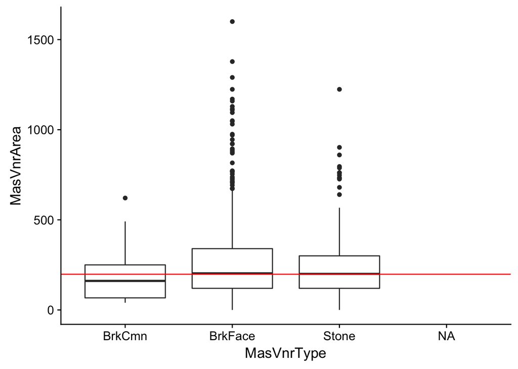

```r
allSet$MasVnrType[is.na(allSet$MasVnrType) & is.na(allSet$MasVnrArea)] <- "None"
allSet$MasVnrArea[is.na(allSet$MasVnrArea)] <- 0
missArea <- allSet$MasVnrArea[is.na(allSet$MasVnrType)]
allSet[allSet$MasVnrType != "None", c("MasVnrType","MasVnrArea")] %>%
        ggplot(aes(x = MasVnrType, y = MasVnrArea)) +
        geom_boxplot()+
        geom_hline(yintercept = missArea, color = "red")
```

```r
medMason <- allSet[allSet$MasVnrType != "None", c("MasVnrType","MasVnrArea")] %>%
        group_by(MasVnrType) %>%
        summarize(median = median(MasVnrArea))
```

The nearest masonry type to the missing values is *Stone*. Hence, I will replace the missing value by *Stone*.

```r
rIndx <- which(is.na(allSet$MasVnrType))
for(i in rIndx){
        medVal <- medMason[which((abs(medMason$median - allSet$MasVnrArea[i])) == min(abs(medMason$median - allSet$MasVnrArea[i]), na.rm = T)),"MasVnrType"]
         allSet$MasVnrType[i] <- medVal[[1]]
}
```

```r
missZoning <- unique(allSet$MSSubClass[is.na(allSet$MSZoning)])
```

```r
allSet$MSZoning[is.na(allSet$MSZoning) & allSet$MSSubClass %in% c(70,30)] <- "RM"
allSet$MSZoning[is.na(allSet$MSZoning) & allSet$MSSubClass == 20] <- "RL"
```

- **SaleType**:

Most *Normal* SaleCondition have a *WD* SaleType. So, I’ll impute the missing value with the same.

```r
allSet$SaleType[is.na(allSet$SaleType)] <- "WD"
```

- **Electrical**: It can be directly related to the overall condition of the house (*OverallCond*).

Most of 5-rating Overall Condition houses have *SBrkr* electrical system.

```r
allSet$Electrical[is.na(allSet$Electrical)] <- "SBrkr"
```

For a *KitchenAbvGr* of 1, the most likely value for a *KitchenQual* is *TA*.

```r
allSet$KitchenQual[is.na(allSet$KitchenQual)] <- "TA"
```

- **PoolQC**:

Out of the 2909 houses with missing PoolQC values, we have 2906 with zero PoolArea. These PoolQC values can be imputed with *None*.

```r
allSet$PoolQC[allSet$PoolArea == 0] <- "None"
```

Impute missing PoolQC values with the values of nearest PoolArea means.

```r
rIndx <- which(is.na(allSet$PoolQC) & allSet$PoolArea >0)
meanArea <- allSet[!is.na(allSet$PoolQC),c("PoolQC","PoolArea")] %>%
        group_by(PoolQC) %>%
        summarize(AreaMean = round(mean(PoolArea),0))

for(i in rIndx){
        poolQc <- meanArea[which((abs(meanArea$AreaMean - allSet$PoolArea[i])) == min(abs(meanArea$AreaMean - allSet$PoolArea[i]), na.rm = T)),"PoolQC"]
        allSet$PoolQC[i] <- poolQc[[1]]
}
```

- **Garage** features: We have 7 features all related to garage and have maximum number of missing values of 159 in *GarageYrBlt* column.

```r
garageCols <- names(allSet)[grepl("Garage.*", names(allSet))]
garageCols
```

```
## [1] "GarageType"   "GarageYrBlt"  "GarageFinish" "GarageCars"
## [5] "GarageArea"   "GarageQual"   "GarageCond"
```

I will consider houses with a complete set of *NAs* or zeros- as explained above- as houses with *None* values.

```r
noGarage <- which((is.na(allSet$GarageArea) | allSet$GarageArea == 0)
                  & (is.na(allSet$GarageCars) | allSet$GarageCars == 0)
                  & is.na(allSet$GarageCond)
                  & is.na(allSet$GarageFinish)
                  & is.na(allSet$GarageQual)
                  & is.na(allSet$GarageType)
                  & (is.na(allSet$GarageYrBlt) | allSet$GarageYrBlt == 0))

allSet[noGarage,c("GarageType","GarageFinish","GarageQual","GarageCond")] <- "None"

allSet[noGarage, c("GarageYrBlt","GarageCars","GarageArea")] <- 0

missGarage <- which(is.na(allSet$GarageArea)
                    | is.na(allSet$GarageCars)
                    | is.na(allSet$GarageCond)
                    | is.na(allSet$GarageFinish)
                    | is.na(allSet$GarageQual)
                    | is.na(allSet$GarageType)
                    | is.na(allSet$GarageYrBlt))
```

House *2577* is missing more values than house *2127*. Hence, I will impute its missing values first based on the matching values of houses of the same *GarageType* and *GarageYrBlt*.

```r
miss <- which(is.na(allSet$GarageCars) | is.na(allSet$GarageArea))

grpdVals1 <- allSet%>%
        group_by(GarageType, GarageYrBlt, GarageFinish, GarageQual, GarageCond) %>%
        summarize(medCars = median(GarageCars), meanArea = round(mean(GarageArea),0),count = n()) %>%
        arrange(desc(count))
comp <- complete.cases(grpdVals1)
grpdVals1 <- grpdVals1[comp,]
grpdVals1
```

```
## # A tibble: 601 x 8
## # Groups:   GarageType, GarageYrBlt, GarageFinish, GarageQual [553]
##    GarageType GarageYrBlt GarageFinish GarageQual GarageCond medCars
##    <chr>            <dbl> <chr>        <chr>      <chr>        <dbl>
##  1 None                 0 None         None       None          0
##  2 Attchd            2006 RFn          TA         TA            2.00
##  3 Attchd            2005 Fin          TA         TA            2.00
##  4 Attchd            2007 Fin          TA         TA            3.00
##  5 Attchd            2005 RFn          TA         TA            2.00
##  6 Attchd            2006 Fin          TA         TA            2.00
##  7 Attchd            2004 Fin          TA         TA            2.00
##  8 Attchd            2007 RFn          TA         TA            2.00
##  9 Attchd            2003 Fin          TA         TA            2.00
## 10 Attchd            2008 Fin          TA         TA            3.00
## # ... with 591 more rows, and 2 more variables: meanArea <dbl>,
## #   count <int>
```

```r
rIndx <- miss
for(i in rIndx){
    missVals <- grpdVals1[which((grpdVals1$GarageYrBlt == allSet$GarageYrBlt[i]) & (grpdVals1$GarageType == allSet$GarageType[i])),c("GarageFinish", "medCars", "meanArea", "GarageQual","GarageCond")]
        allSet$GarageFinish[i] <- missVals[[1]][1]
        allSet$GarageCars[i] <- missVals[[2]][1]
        allSet$GarageArea[i] <- missVals[[3]][1]
        allSet$GarageQual[i] <- missVals[[4]][1]
        allSet$GarageCond[i] <- missVals[[5]][1]
  }
```

Then I will impute its missing values *GarageFinish*, *GarageQual* and *GarageCond* with those having similar *GarageArea*, *GarageCars*, and *GarageType*.

```r
grpdVals <- allSet[allSet$GarageType == "Detchd" & allSet$GarageCars == 1,garageCols] %>%
        group_by(GarageFinish, GarageQual, GarageCond) %>%
        summarize(meanArea = round(mean(GarageArea),0),count = n()) %>%
        arrange(desc(count))
comp <- complete.cases(grpdVals)
grpdVals <- grpdVals[comp,]

rIndx <- missGarage

for(i in rIndx){
    missVals <- grpdVals[which((abs(grpdVals$meanArea - allSet$GarageArea[i])) == min(abs(grpdVals$meanArea - allSet$GarageArea[i]),na.rm = T)),c("GarageFinish", "GarageQual","GarageCond")]
        allSet$GarageFinish[i] <- missVals[[1]][1]
        allSet$GarageQual[i] <- missVals[[2]][1]
        allSet$GarageCond[i] <- missVals[[3]][1]
  }
```

- **Basement** features: By studying the *data_description.txt* file, we find that there are 11 features-listed below- that describe the basements in houses.

```r
bsmtCols <- names(allSet)[grepl("Bsmt.*", names(allSet))]
bsmtCols
```

```
##  [1] "BsmtQual"     "BsmtCond"     "BsmtExposure" "BsmtFinType1"
##  [5] "BsmtFinSF1"   "BsmtFinType2" "BsmtFinSF2"   "BsmtUnfSF"
##  [9] "TotalBsmtSF"  "BsmtFullBath" "BsmtHalfBath"
```

First, let’s check missing values in all Basement features.

```r
bsmtAllNa <- which((allSet[,bsmtCols[1]]== 0 | is.na(allSet[,bsmtCols[1]])) &
                        (allSet[,bsmtCols[2]]== 0 | is.na(allSet[,bsmtCols[2]])) &
                        (allSet[,bsmtCols[3]]== 0 | is.na(allSet[,bsmtCols[3]])) &
                        (allSet[,bsmtCols[4]]== 0 | is.na(allSet[,bsmtCols[4]])) &
                        (allSet[,bsmtCols[5]]== 0 | is.na(allSet[,bsmtCols[5]])) &
                        (allSet[,bsmtCols[6]]== 0 | is.na(allSet[,bsmtCols[6]])) &
                        (allSet[,bsmtCols[7]]== 0 | is.na(allSet[,bsmtCols[7]])) &
                        (allSet[,bsmtCols[8]]== 0 | is.na(allSet[,bsmtCols[8]])) &
                        (allSet[,bsmtCols[9]]== 0 | is.na(allSet[,bsmtCols[9]])) &
                        (allSet[,bsmtCols[10]]== 0 | is.na(allSet[,bsmtCols[10]])) &
                        (allSet[,bsmtCols[11]]== 0 | is.na(allSet[,bsmtCols[11]]))
        )

allSet[bsmtAllNa,c("BsmtQual", "BsmtCond", "BsmtExposure", "BsmtFinType1", "BsmtFinType2")] <- "None"
allSet[bsmtAllNa, c("BsmtFinSF1", "BsmtFinSF2", "BsmtUnfSF", "TotalBsmtSF", "BsmtFullBath", "BsmtHalfBath")] <- 0
```

Now, let’s check remaining basement houses which have missing values but seem to have basements based on at least one non-NA basement feature.

```r
bsmtSmNa <- which(is.na(allSet[,bsmtCols[1]]) |
                          is.na(allSet[,bsmtCols[2]]) |
                          is.na(allSet[,bsmtCols[3]]) |
                          is.na(allSet[,bsmtCols[4]]) |
                          is.na(allSet[,bsmtCols[5]]) |
                          is.na(allSet[,bsmtCols[6]]) |
                          is.na(allSet[,bsmtCols[7]]) |
                          is.na(allSet[,bsmtCols[8]]) |
                          is.na(allSet[,bsmtCols[9]]) |
                          is.na(allSet[,bsmtCols[10]])|
                          is.na(allSet[,bsmtCols[11]]))
bsmtNa <- allSet[bsmtSmNa,bsmtCols]
bsmtNa
```

```
##      BsmtQual BsmtCond BsmtExposure BsmtFinType1 BsmtFinSF1 BsmtFinType2
## 333        Gd       TA           No          GLQ       1124         <NA>
## 949        Gd       TA         <NA>          Unf          0          Unf
## 1488       Gd       TA         <NA>          Unf          0          Unf
## 2041       Gd     <NA>           Mn          GLQ       1044          Rec
## 2186       TA     <NA>           No          BLQ       1033          Unf
## 2218     <NA>       Fa           No          Unf          0          Unf
## 2219     <NA>       TA           No          Unf          0          Unf
## 2349       Gd       TA         <NA>          Unf          0          Unf
## 2525       TA     <NA>           Av          ALQ        755          Unf
##      BsmtFinSF2 BsmtUnfSF TotalBsmtSF BsmtFullBath BsmtHalfBath
## 333         479      1603        3206            1            0
## 949           0       936         936            0            0
## 1488          0      1595        1595            0            0
## 2041        382         0        1426            1            0
## 2186          0        94        1127            0            1
## 2218          0       173         173            0            0
## 2219          0       356         356            0            0
## 2349          0       725         725            0            0
## 2525          0       240         995            0            0
```

We have one house (333) whose *BsmtFinType2* value is missing while its *BsmtFinSF2* is 479 square feet. Let’s see the distribution of all *BsmtFinType2* values versus *BsmtFinSF2*.

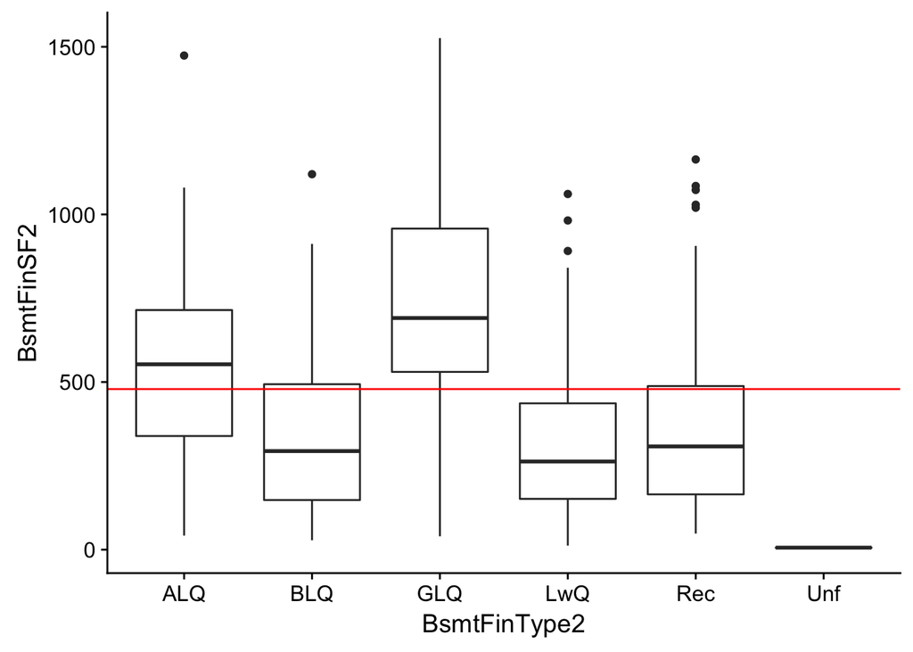

```r
missFinSF2 <- bsmtNa$BsmtFinSF2[is.na(bsmtNa$BsmtFinType2)]
bsmt2 <- allSet[allSet$BsmtFinSF2 >0 & !is.na(allSet$BsmtFinType2), c("BsmtFinSF2", "BsmtFinType2")]
bsmt2 %>% ggplot(aes(x = BsmtFinType2, y = BsmtFinSF2))+
                geom_boxplot()+
                geom_hline(yintercept = missFinSF2, color = "red")
```

```r
medSF <- bsmt2 %>%
        group_by(BsmtFinType2) %>%
        summarize(median = median(BsmtFinSF2))
```

Let’s impute the missing rating of basement finished area (type2) based on the nearest median of square feet for the available type2 ratings.

```r
rIndx <- which(is.na(allSet$BsmtFinType2))

for(i in rIndx){
        bsmtVal <- medSF[which((abs(medSF$median - allSet$BsmtFinSF2[i])) == min(abs(medSF$median - allSet$BsmtFinSF2[i]), na.rm = T)),"BsmtFinType2"]
         allSet$BsmtFinType2[i] <- bsmtVal[[1]]
}
```

For basement exposure (*BsmtExposure*), we have 3 missing values. Let’s see if there’s any relationship between basement types and exposure.

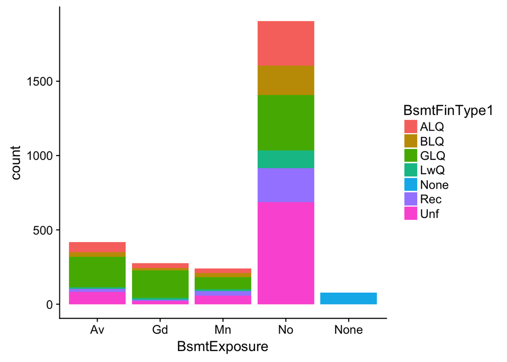

```r
allSet[!is.na(allSet$BsmtExposure), c("BsmtExposure","BsmtFinType1")] %>%
        ggplot(aes(x = BsmtExposure, fill = BsmtFinType1))+
        geom_histogram(stat = "count")
```

```r
allSet$BsmtExposure[is.na(allSet$BsmtExposure)] <- "No"
```

Then taking *TA* as the value of the missing basement quality houses.

```r
allSet$BsmtQual[is.na(allSet$BsmtQual)] <- "TA"
```

The majority of *TA* and *Gd* quality have *TA* basement condition. So, we’ll use *TA* basement condition for the missing values.

```r
allSet$BsmtCond[is.na(allSet$BsmtCond)] <- "TA"
```

# 2 Feature Engineering

## 2.1 Apply log transformation on skewed variables

```r
allSetNew <- allSet

featureClasses <- sapply(names(allSetNew), function(x){class(allSetNew[[x]])})

numFeatures <- names(featureClasses[featureClasses == "numeric" | featureClasses == "integer"])

charFeatures <- names(featureClasses[featureClasses == "character"])

skewedVals <- sapply(numFeatures, function(x){skewness(allSetNew[[x]],na.rm = T)})

skewedFeatures <- skewedVals[skewedVals < -2 | skewedVals > 2]

for (i in names(skewedFeatures)) {
        allSetNew[[i]] <- log(allSetNew[[i]] + 1)
}
```

## 2.2 Change some character features into dummy variables

```r
dummies <- dummyVars(~., allSetNew[charFeatures])
dummyVariables <- predict(dummies, allSetNew[charFeatures])

allSetNew <- cbind(allSetNew[numFeatures], dummyVariables)
```

# 3 Machine learning modeling

First, I will re-split the full data set into its original *train* and *test* sets.

```r
salesPriceNA <- which(is.na(allSetNew["SalePrice"]))
train <- allSetNew[-salesPriceNA,]
test <- allSetNew[salesPriceNA,]
```

## 3.1 Ridge Regression

Ridge Regression is a remedial measure taken to alleviate multicollinearity amongst regression predictor variables in a model.

```r
train.Matrix =as.matrix(train[,names(train) != c("Id","SalePrice")])
test.Matrix = as.matrix(test[,names(test) != c("Id","SalePrice")])

train.y = log(train$SalePrice + 1)
```

```r
set.seed(4)

grid = 10^seq(10,-2, length = 100)

ridge.mod <- glmnet(train.Matrix,train.y,alpha = 0, lambda = grid)
dim(coef(ridge.mod))
```

```
## [1] 303 100
```

We have 303 regression coefficients with 100 lambda values. Then, I will split the *train* data set into *training* and *testing* subsets to estimate the test error.

```r
set.seed(5)
nTrain <- round(0.75 * nrow(train.Matrix))
sampleTrain <- sample(nrow(train.Matrix),nTrain)
training <- train.Matrix[sampleTrain,]
testing <- train.Matrix[-sampleTrain,]
training.y <- train.y[sampleTrain]
testing.y <- train.y[-sampleTrain]
```

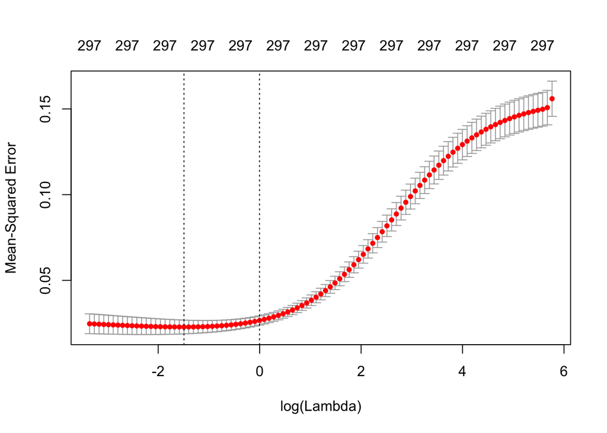

```r
set.seed(1)
cv.out <- cv.glmnet(training, training.y, alpha = 0)
plot(cv.out)
```

```r
ridgeBestLambda <- cv.out$lambda.min
ridgeBestLambda;log(ridgeBestLambda)
```

```
## [1] 0.2249694
```

```
## [1] -1.491791
```

The best lambda value is *0.2249694*. Let’s see the test *RMSE* associated with this value of lambda.

```r
ridge.predict <- predict(ridge.mod,s = ridgeBestLambda, newx = testing)
ridge.rmse <- sqrt(mean((ridge.predict-testing.y)^2))
ridge.rmse
```

```
## [1] 0.09866289
```

So, the test error (*RMSE*) resulted from the Ridge Regression model on the testing data is *0.0986629*.

## 3.2 Lasso Regression

LASSO is a regression analysis method that performs both variable selection and regularization in order to enhance the prediction accuracy and interpretability of the statistical model it produces.

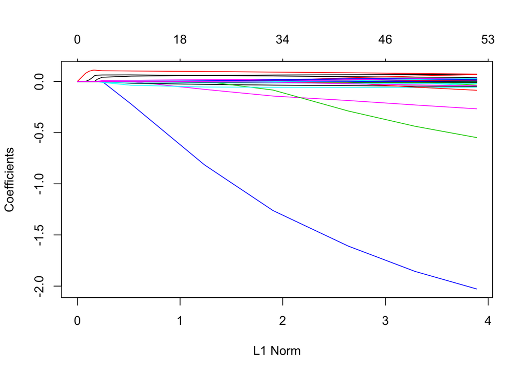

```r
set.seed(5)
lasso.mod = glmnet(train.Matrix,train.y,alpha = 1, lambda = grid)
plot(lasso.mod)
```

Then, let’s perform cross validation and see the test error.

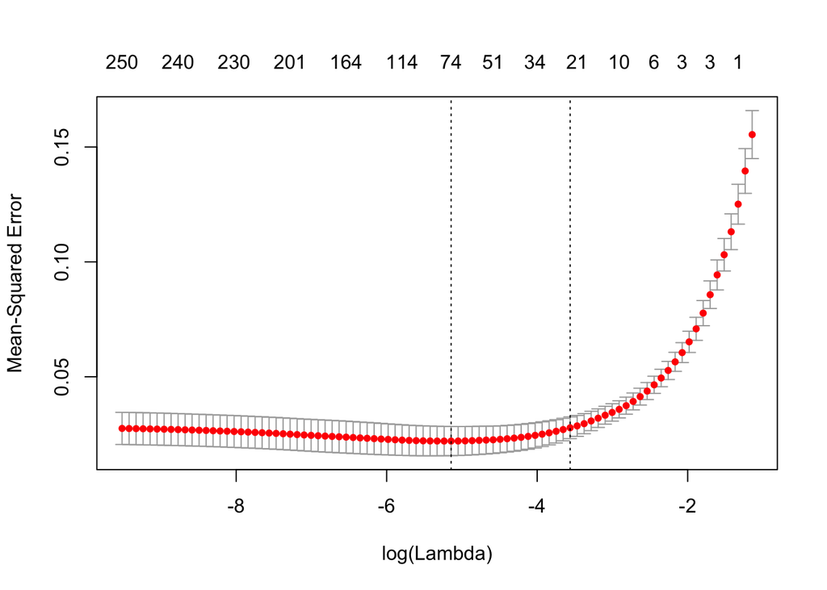

```r
set.seed(1)
cv.out <- cv.glmnet(training, training.y, alpha = 1)
plot(cv.out)
```

```r
lassoBestlambda <- cv.out$lambda.min
lassoBestlambda;log(lassoBestlambda)
```

```
## [1] 0.00583801
```

```
## [1] -5.143365
```

The best lambda value that results in the smallest cross validation error is *0.005838*.

```r
lasso.predict <- predict(lasso.mod,s = lassoBestlambda, newx = testing)
lasso.rmse <- sqrt(mean((lasso.predict-testing.y)^2))
lasso.rmse
```

```
## [1] 0.110181
```

So, the RMSE resulted from the Lasso Regression model is *0.110181* which is slightly higher than that of the Ridge Regression.

```r
lasso.coef <- predict(lasso.mod,type = "coefficients", s = lassoBestlambda)[1:303,]
names(lasso.coef[lasso.coef !=0])
```

```
##  [1] "(Intercept)"          "LotArea"              "OverallQual"
##  [4] "OverallCond"          "YearBuilt"            "YearRemodAdd"
##  [7] "BsmtFinSF1"           "TotalBsmtSF"          "GrLivArea"
## [10] "BsmtFullBath"         "KitchenAbvGr"         "Fireplaces"
## [13] "GarageCars"           "GarageArea"           "WoodDeckSF"
## [16] "OpenPorchSF"          "ScreenPorch"          "MSZoningC (all)"
## [19] "MSZoningRM"           "NeighborhoodCrawfor"  "NeighborhoodEdwards"
## [22] "NeighborhoodNridgHt"  "NeighborhoodSomerst"  "NeighborhoodStoneBr"
## [25] "Condition1Artery"     "Condition1Norm"       "Condition2PosN"
## [28] "RoofMatlClyTile"      "Exterior1stBrkComm"   "Exterior1stBrkFace"
## [31] "ExterQualTA"          "ExterCondFa"          "FoundationPConc"
## [34] "BsmtQualEx"           "BsmtCondFa"           "BsmtExposureGd"
## [37] "BsmtFinType1GLQ"      "BsmtFinType1Unf"      "HeatingGrav"
## [40] "HeatingQCEx"          "CentralAirN"          "KitchenQualEx"
## [43] "KitchenQualTA"        "FunctionalMaj2"       "FunctionalSev"
## [46] "FunctionalTyp"        "FireplaceQuNone"      "GarageTypeAttchd"
## [49] "GarageFinishUnf"      "GarageCondTA"         "PavedDriveN"
## [52] "PavedDriveY"          "SaleTypeNew"          "SaleConditionAbnorml"
```

Number of coefficients that the Lasso Regression picked (not zero) is 54.

## 3.3 Gradient Boosting Machine (GBM) Algorithm

Gradient boosting is a machine learning technique for regression and classification problems, which produces a prediction model in the form of an ensemble of weak prediction models, typically decision trees.

```r
set.seed(5)
# re-split the combined data
salesPriceNA <- which(is.na(allSetNew["SalePrice"]))
train <- allSetNew[-salesPriceNA,]
test <- allSetNew[salesPriceNA,]

train$SalePrice <- log(train$SalePrice + 1)

nTrain <- round(0.75 * nrow(train))

sampleTrain <- sample(nrow(train),nTrain)

training <- train[sampleTrain,!names(train) == "Id"]
testing <- train[-sampleTrain,!names(train) == "Id"]

testing.y <- testing$SalePrice
```

Build the *GBM* model.

```r
set.seed(2)
control <- trainControl(method = "repeatedcv", number = 10, repeats = 5, verboseIter = FALSE)

gbm.mod <- train(SalePrice~., data = training, method = "gbm", trControl = control, verbose = FALSE)

gbm.mod
```

```
## Stochastic Gradient Boosting
##
## 1095 samples
##  302 predictor
##
## No pre-processing
## Resampling: Cross-Validated (10 fold, repeated 5 times)
## Summary of sample sizes: 985, 984, 985, 985, 985, 986, ...
## Resampling results across tuning parameters:
##
##   interaction.depth  n.trees  RMSE       Rsquared   MAE
##   1                   50      0.1754895  0.8277985  0.12294897
##   1                  100      0.1491191  0.8595910  0.10367975
##   1                  150      0.1427706  0.8688748  0.09846921
##   2                   50      0.1536606  0.8551644  0.10579030
##   2                  100      0.1399041  0.8737287  0.09511092
##   2                  150      0.1364623  0.8796950  0.09257943
##   3                   50      0.1453491  0.8670813  0.09885915
##   3                  100      0.1357116  0.8811948  0.09180459
##   3                  150      0.1335058  0.8851087  0.09033930
##
## Tuning parameter 'shrinkage' was held constant at a value of 0.1
##
## Tuning parameter 'n.minobsinnode' was held constant at a value of 10
## RMSE was used to select the optimal model using the smallest value.
## The final values used for the model were n.trees = 150,
##  interaction.depth = 3, shrinkage = 0.1 and n.minobsinnode = 10.
```

Let’s see the test error (RMSE) by applying the GBM model to the testing data set.

```r
gbm.predict <- predict(gbm.mod,newdata = testing)
gbm.rmse <- sqrt(mean((gbm.predict-testing.y)^2))
gbm.rmse
```

```
## [1] 0.1203715
```

Therefore, GBM model resulted in a worse prediction than that of both Ridge and Lasso.

## 3.4 Linear Model with Forward Stepwise

The term “linear” refers to the fact that we are fitting a line. The term model refers to the equation that summarizes the line that we fit.

```r
set.seed(4)

null_model <- lm(SalePrice~1, data = training)

full_model <- lm(SalePrice~., data = training)

step_model <- step(null_model, scope = list(lower = null_model, upper = full_model), direction = "forward")
```

Let’s see the test error (RMSE) by applying the Step Wise model to the testing data set.

```r
step.predict <- predict(step_model,newdata = testing)
step.rmse <- sqrt(mean((step.predict-testing.y)^2))
step.rmse
```

```
## [1] 0.1472766
```

The RMSE resulted from the Linear model with Forward Stepwise is *0.1472766*.

# 4 Model predicting on the test data

By now we have trained and tested four models. We will use each one to predict the Sale Price response variable in the original *test* data set.

```r
test.predict.step <- exp(predict(step_model,newdata = test)) - 1

test.predict.ridge <- exp(predict(ridge.mod,s = ridgeBestLambda,newx = test.Matrix))-1

test.predict.lasso <- exp(predict(lasso.mod, s = lassoBestlambda, newx = test.Matrix))-1

test.predict.gbm <- exp(predict(gbm.mod,newdata = test)) - 1
```

# 5 Models Ensembling and getting the outcome

Ensemble methods use multiple learning algorithms to obtain better predictive performance than could be obtained from any of the constituent learning algorithms alone.

```r
ensmb.df <- data.frame(Model = c("ridge", "lasso", "gbm", "step"), RMSE = c(ridge.rmse,lasso.rmse,gbm.rmse,step.rmse), Weight = c(40,30,15,15))

solution <- data.frame(Id = as.integer(rownames(test)),SalePrice =  as.numeric(test.predict.ridge*.4 + test.predict.lasso*.3 + test.predict.gbm*.15 + test.predict.step*.15))
```